# Discrete random variables in R

MACS 33001 University of Chicago

$$\newcommand{\E}{\mathrm{E}} \newcommand{\Var}{\mathrm{Var}} \newcommand{\Cov}{\mathrm{Cov}}$$

## Functions for working with probabilities

- Common core functions for probability distributions
- `d*()` - density function
- `p*()` - distribution function
- `r*()` - random data generation

## Binomial

| To find this binomial probability | Use this R command |
| --- | --- |
| $\Pr(x = a)$ | `dbinom(x = a, size = n, prob = p)` |
| $\Pr(x \leq a)$ | `pbinom(q = a, size = n, prob = p)` |
| $\Pr(x < a)$ | `pbinom(q = a - 1, size = n, prob = p)` |
| $\Pr(x \geq a) = 1 - \Pr(x \leq a) = 1 - \Pr (x \leq a-1)$ | `1 - pbinom(q = a - 1, size = n, prob = p)` |
| $\Pr(x > a) = 1 - \Pr(x \leq a)$ | `1 - pbinom(q = a, size = n, prob = p)` |

## Calculating probabilities

$$\begin{eqnarray}
p_X(k) & = & {{N}\choose{k}}\pi^{k} (1- \pi)^{n-k}
\end{eqnarray}$$

## Calculating probabilities

$$N = 10, k = 5, \pi = .5$$

```r
N <- 10
k <- 5
prob <- .5
```

[output not shown]

## Calculating probabilities

$$N = 20, k = 5, \pi = .4$$

```r
N <- 20
k <- 5
prob <- .4
```

[output not shown]

## Calculating probabilities

$$N = 1, k = 1, \pi = .4$$

```r
N <- 1
k <- 1
prob <- .4
```

[output not shown]

## Simulating random variables

- $N = 10, \pi = .5$
- Simulate 1000 observations

  ```r
  set.seed(1234)

  # store in a vector
  rbinom(1000, size = 10, prob = .5)
  ```

  ```
  ##    [1]  3  5  5  6  7  6  1  4  6  5  6  5  4  7  4  7  4  4  4  4  4  4  3
  ##   [24]  2  4  6  5  7  7  2  5  4  4  5  4  6  4  4  9  6  5  6  4  5  4  5
  ##   [47]  6  5  4  6  3  4  6  5  3  5  5  6  4  7  7  2  4  2  4  6  4  5  2
  ##   [70]  5  3  7  2  6  3  5  5  3  4  6  7  5  3  5  4  7  5  4  3  7  3  7
  ##   [93]  3  3  3  5  4  2  4  6  2  5  4  4  3  4  3  3  5  2  6  3  8  3  4
  ##  [116]  7  8  4  3  6  6  7  9  7  5  4  4  5  5  4  8  6  3  5  7  5  7  5
  ##  [139]  6  7  5  8  4  5  4  6  6  5  8  5  5  4  3  7  4  8  5  9  4  5  5
  ##  [162]  5  5  4  3  6  5  3  6  4  6  5  6  5  4  6  5  5  3  4  5  4  5  3
  ##  [185]  8  2  7  6  4  6  6  9  3  7  6  6  7  6  8  6  6  5  4  6  5  6  4
  ##  [208]  5  4  8  5  4  4  6  5  7  6  6  5  7  5  2  4  4  3  5  6  4  5  5
  ##  [231]  6  5  3  6  5  4  6  4  5  9  5  4  4  6  8  5  6  5  8  6  5  5  4
  ##  [254]  4  3  5  4  1  5  5  7  2  5  4  3  3  6  2  2  6  4  6  4  6  2  5
  ##  [277]  6  5  4  4  4  5  7  6  6  4  5  4  6  6  6  5  8  4  5  6  6  3  6
  ##  [300]  4  4  8  5  5  8  5  4  9  5  6  7  6  5  5  3  4  4  5  4  7  4  7
  ##  [323]  5  3  4  4  5  4  6  7  6  7  8  4  5  5  4  2  7  5  8  4  5  8  4
  ```

  [output cut: 29 more lines]

  ```r
  # store in a data frame
  data_frame(x = rbinom(1000, size = 10, prob = .5))
  ```

  ```
  ## # A tibble: 1,000 x 1
  ##        x
  ##    <int>
  ##  1     7
  ##  2     5
  ##  3     3
  ##  4     4
  ##  5     6
  ##  6     5
  ##  7     5
  ##  8     3
  ##  9     8
  ## 10     8
  ## # ... with 990 more rows
  ```

## Simulating multiple draws

```r
rerun(.n = 10, rbinom(10, size = 10, prob = .5)) %>%
  bind_cols()
```

```
## # A tibble: 10 x 10
##       V1    V2    V3    V4    V5    V6    V7    V8    V9   V10
##    <int> <int> <int> <int> <int> <int> <int> <int> <int> <int>
##  1     3     2     7     5     5     4     7     4     5     7
##  2     4     7     7     5     5     5     5     3     2     6
##  3     5     6     7     4     4     7     3     7     3     6
##  4     5     4     2     5     8     5     4     4     5     3
##  5     3     5     3     1     5     6     3     5     4     5
##  6     6     4     7     5     8     7     8     6     5     4
##  7     6     4     4     5     4     5     4     4     6     2
##  8     2     6     4     4     4     5     4     6     1     7
##  9     6     6     5     3     4     3     3     6     8     4
## 10     4     4     3     5     5     5     2     4     4     5
```

## Simulating multiple draws

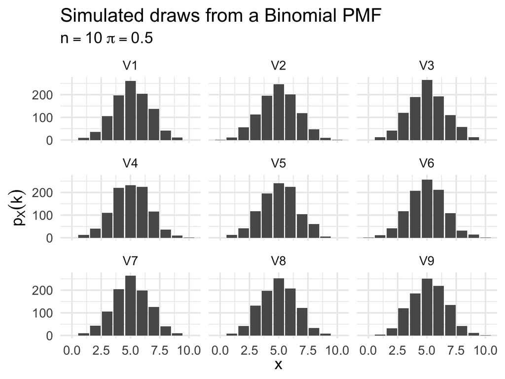

```r
rerun(.n = 9, rbinom(1000, size = 10, prob = .5)) %>%
  bind_cols() %>%
  gather(var, value) %>%
  ggplot(aes(value)) +
  geom_bar() +
  facet_wrap(~var) +
    labs(title = "Simulated draws from a Binomial PMF",
         subtitle = expression(n == 10 ~ pi == .5),
         x = expression(x),
         y = expression(p[X] (k)))
```

## Setting the seed

```r
# draw #1
set.seed(1234)
rbinom(10, size = 10, prob = .5)
```

```
##  [1] 3 5 5 6 7 6 1 4 6 5
```

```r
# draw #2
set.seed(1234)
rbinom(10, size = 10, prob = .5)
```

```
##  [1] 3 5 5 6 7 6 1 4 6 5
```

## Poisson

| To find this Poisson probability | Use this R command |
| --- | --- |
| $\Pr(x = a)$ | `dpois(x = a, lambda = p)` |
| $\Pr(x \leq a)$ | `ppois(q = a, lambda = p)` |
| $\Pr(x < a)$ | `ppois(q = a - 1, lambda = p)` |
| $\Pr(x \geq a) = 1 - \Pr(x \leq a) = 1 - \Pr (x \leq a-1)$ | `1 - ppois(q = a - 1, lambda = p)` |
| $\Pr(x > a) = 1 - \Pr(x \leq a)$ | `1 - ppois(q = a, lambda = p)` |

## Calculating probabilities

$$N = 3, \lambda = 5$$

```r
N <- 3
lambda <- 5
```

| To find this Poisson probability | Use this R command | Results |
| --- | --- | --- |
| $\Pr(x = 3)$ | `dpois(x = N, lambda = lambda)` | 0.14 |
| $\Pr(x \leq 3)$ | `ppois(q = N, lambda = lambda)` | 0.265 |
| $\Pr(x < 3)$ | `ppois(q = N - 1, lambda = lambda)` | 0.125 |
| $\Pr(x \geq 3) = 1 - \Pr(x \leq 3) = 1 - \Pr (x \leq 3-1)$ | `1 - ppois(q = N - 1, lambda = lambda)` | 0.875 |
| $\Pr(x > 3) = 1 - \Pr(x \leq 3)$ | `1 - ppois(q = N, lambda = lambda)` | 0.735 |

## Calculating probabilities

$$N = 12, \lambda = 17.3$$

```r
N <- 12
lambda <- 17.3
```

[output not shown]

## Simulating random variables

- $N = 12, \lambda = 17.3$
- Simulate 1000 observations

  ```r
  set.seed(1234)

  # store in a vector
  (X <- rpois(1000, lambda = 17.3))
  ```

  ```
  ##    [1] 12 18 18 14 19 14 21 14 15 10 17 21 16 15 20 14 17 15 17 17 20 15 13
  ##   [24] 20 21 31 24 11 23 12 22 15 13 12 15 20 17 13 13 25 20 27 17 14 15 12
  ##   [47] 16 18 21 26 17 18 17 18 14 14 29 17 18 14 16 20 20 19 15 17 15 18 24
  ##   [70] 21 15 27 22 21 19 18 17 20 19 16 26 14 17 18 17 16 14 17 15 20 12 13
  ##   [93] 17 16 14 17 18 20 18 14 14 17 29 15 17 17 15 23 19 16 19 18 24 18 19
  ##  [116] 18 15 16 16 27 20 19 16 13 15 21 13 16 18 19 24 17 15 16 14 15 19 10
  ##  [139] 12 23 19 20 17 15 19 21 25 22 15 11 15 12 19 26 19 19 13 17 15 20 18
  ##  [162] 20 18 20 24 21 17 12 22 12 10 14 16 14 23 18 22 17 17 18  9 29 20 14
  ##  [185] 10 16 13 16 18 14 16 17 19 17 19 12 19 13 22 18 18 18 19 21 19 20 12
  ##  [208] 24 18 20 11 21 15 20 10 14 20 27 18 17 18 14 21 25 14 13 17 18 13 21
  ##  [231] 21 18 10 13 16 16 21 27 24 24 12 19 19 12 13 16 13 14 11 15 17 10 15
  ##  [254] 23 18 18 17 21 21 15 17 15 22 20 19 16 17  9 18 21 15 14 12 14 16 13
  ##  [277] 12 21 22 17 22 14 11 15 18 16 12 10 25 12 16 25 21 25 17 16 15  7 18
  ##  [300] 17 26 14 28 20 21 22 23 18 18 18 18 18 15 21 18 11 15 26 22 19 19 17
  ##  [323] 13 22 14 13 16 13 12 20 16 15 14 16 16 20 23 19 13 12 13 17 20 17 23
  ```

  [output cut: 29 more lines]

- What is the expected value of $X$? Its variance?

  ```r
  mean(X)
  ```

  ```
  ## [1] 17.4
  ```

  ```r
  var(X)
  ```

  ```
  ## [1] 17
  ```

## Lincoln Tunnel

> If 85% of vehicles arriving at the Lincoln Tunnel (connecting New Jersey and New York City) have either New York or New Jersey license plates, what is the probability that, of the next 20 vehicles, 2 or fewer (that is, 0, 1, or 2) will bear license plates from states other than New Jersey or New York?

## Lincoln Tunnel

$$\begin{eqnarray}
p_X(k) & = & {{N}\choose{k}}\pi^{k} (1- \pi)^{n-k}
\end{eqnarray}$$

- $N = 20$ and $p=0.15$
- Calculate the probability that 0, 1, or 2 of the next cars will bear license plates from states other than New Jersey or New York

## Lincoln Tunnel

One way to state the problem is:

$$\sum_{k = 0}^2 {{N}\choose{k}}\pi^{k} (1- \pi)^{n-k} = \sum_{k = 0}^2 {{20}\choose{k}} 0.15^{k} (1- 0.15)^{20-k}$$

```r
dbinom(0, 20, 0.15) + dbinom(1, 20, 0.15) + dbinom(2, 20, 0.15)
```

```
## [1] 0.405
```

## Lincoln Tunnel

Alternatively, we can frame this in terms of the CDF:

$$F_X(x) = \Pr (X \leq 2) = \sum_{k \leq 2} p_X(k)$$

```r
pbinom(2, 20, 0.15)
```

```
## [1] 0.405
```

## Booking travel

> Book4Less.com is an online travel website that offers competitive prices on airline and hotel bookings. During a typical weekday, the website averages 10 visits per minute.
1. What is the probability that there will be at least 7 but no more than 12 visits in the next minute?
2. What is the probability there will be more than 12 visits in the next minute?

## Probability that there will be at least 7 but no more than 12 visits in the next minute

$$F_X(x) = \Pr (7 \leq x \leq 12) = \sum_{k = 7}^{12} e^{-10} \frac{10^{k}}{k!}$$

```r
dpois(7:12, 10)
```

```
## [1] 0.0901 0.1126 0.1251 0.1251 0.1137 0.0948
```

```r
sum(dpois(7:12, 10))
```

```
## [1] 0.661
```

```r
ppois(12, 10) - ppois(6, 10)
```

```
## [1] 0.661
```

## Probability there will be more than 12 visits in the next minute

$$F_X(x) = \Pr (x > 12) = \sum_{k = 13}^{\infty} e^{-10} \frac{10^{k}}{k!}$$

```r
sum(dpois(13:50, 10))
```

```
## [1] 0.208
```

```r
1 - ppois(12, 10)
```

```
## [1] 0.208
```